# Beyond the Stage

Margaret Sun

4/5/2019

## Final Project Milestone

#### Question:

Twitter API portions to come: if we are not looking at Python ever again in class, am I allowed to use it for the Final Project?

#### Data Description:

- Data included thus far represents the fundamental organization of the project, by tour dates and locations for the band BTS’ world tour, “BTS World Tour: Love Yourself”.
- “love_yourself” includes all dates, geographic locations, attendance, and revenue of each concert stop
- Attendance and revenue for the following shows were found as the sum of all shows at the respective location: Seoul, North American cities, London, Berlin, Paris, Japan cities, Taoyuan, Hong Kong, Bangkok
- Data for each show is the sum divided by the number of shows per city, and may differ from actual venues, consider redividing in proportion to relative stadium capacities
- While the source is the summary chart for the Wikipedia page for “BTS World Tour: Love Yourself”, each of the numbers in the chart links to local coverage of concert sales, pulling from numerous news sources

#### Sample Graphic

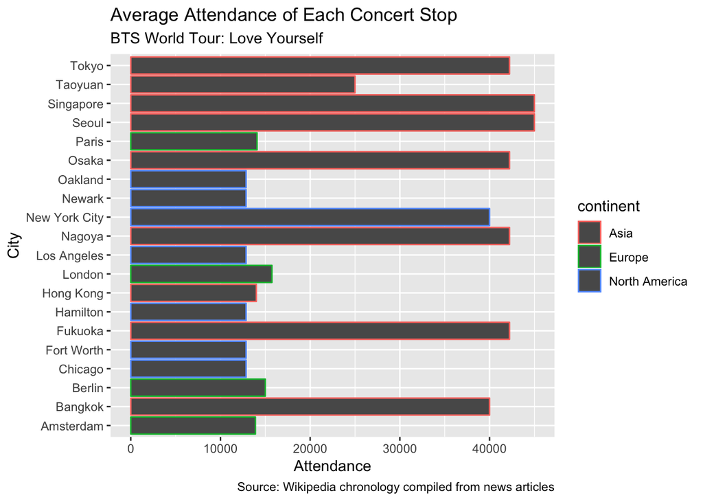